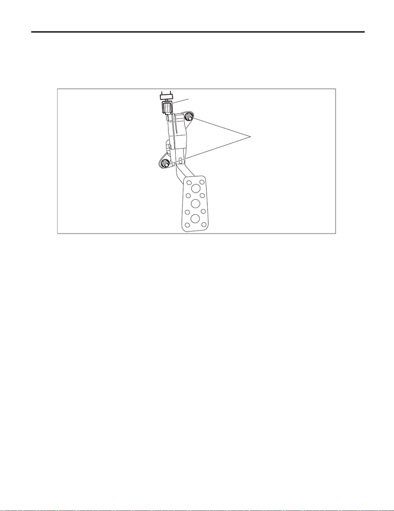

SP(w/o STI)-4

Accelerator Pedal

SPEED CONTROL SYSTEMS

2. Accelerator Pedal

A: REMOVAL

1) Disconnect the ground terminal from battery sensor. <Ref. to NT-5, BATTERY, NOTE, Note.>

B: INSTALLATION

Install in the reverse order of removal.

Tightening torque:

7.5 N·m (0.8 kgf-m, 5.5 ft-lb)

C: DISASSEMBLY

NOTE:

The accelerator pedal cannot be disassembled.

D: INSPECTION

1. CHECK ACCELERATOR PEDAL SENSOR AREA (METHOD WITH CIRCUIT TESTER)

1) Disconnect the ground terminal from battery sensor. <Ref. to NT-5, BATTERY, NOTE, Note.>

2) Remove the ECM. <Ref. to FU(w/o STI)-132, REMOVAL, Engine Control Module (ECM).>

ST 18460AA030 CHECK BOARD

4) Connect the ground terminal to battery sensor. <Ref. to NT-5, BATTERY, NOTE, Note.>

5) Turn the ignition switch to ON. (engine OFF)

SP-02142

(B)

(A)

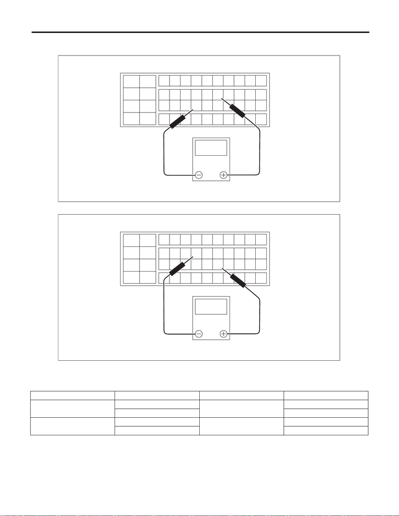

SP(w/o STI)-5

Accelerator Pedal

SPEED CONTROL SYSTEMS

6) Measure the voltage between ECM connector terminals using ST.

Main sensor side

Sub sensor side

7) After inspection, install the related parts in the reverse order of removal.

(A) To the check board connector

(ECM connector)

Accelerator pedal sensor Accelerator pedal Terminal No. Standard

Main

Not depressed (full closed)

17 (+) and 31 (–)

0.4 — 1.0 V

Depressed (full opened) 2.4 — 3.7 V

Sub

Not depressed (full closed)

29 (+) and 19 (–)

0.4 — 1.0 V

Depressed (full opened) 2.4 — 3.7 V

SP-02123

(A)

3

5

6

12

45

21

33

V

SP-02124

(A)

10

3

5

6

12

45

21

33

V

[figure not shown]

SP(w/o STI)-6

Accelerator Pedal

SPEED CONTROL SYSTEMS

1) Turn the ignition switch to ON. (engine OFF)

2) Read the accelerator pedal opening angle signal and voltage of accelerator pedal sensor using Subaru

Select Monitor. <Ref. to EN(w/o STI)(diag)-37, DISPLAY CURRENT ENGINE DATA, OPERATION, Subaru

Select Monitor.>

3. OTHER INSPECTIONS

1) Check that the accelerator pedal does not have deformation, cracks or damage.

2) Check for smooth operation when the accelerator pedal is depressed.

3) Check if the accelerator pedal returns to its original position smoothly when the pedal is released.

Accelerator pedal sensor Accelerator pedal opening angle signal Standard

Main

0.0% 0.4 — 1.0 V

100.0% 2.4 — 3.7 V

Sub

0.0% 0.4 — 1.0 V

100.0% 2.4 — 3.7 V

[figure not shown]

IGNITION

IG(w/o STI)

Page